*Draft! Prepared 2021-09-24 using country-reported data CSV files dated 2021-09-13 and estimates files dated 2021-08-16.*

### Fig. 4.1 The global number of people provided with TB preventive treatment, 2015–2020<sup>a</sup>

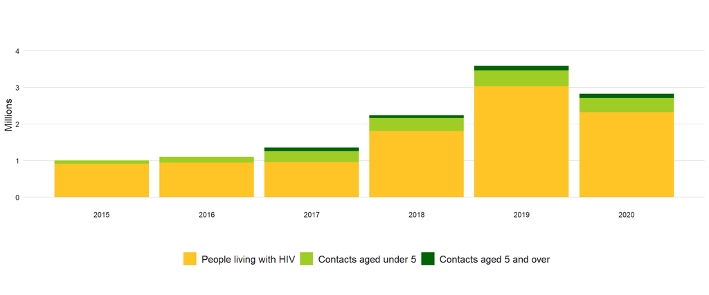

<sup>a</sup> The number of people living with HIV who were provided with TB preventive treatment in 2019 is lower than published in the 2020 Global Tuberculosis Report. This is due to an update of the data reported by India.

### Fig. 4.2 Global progress in provision of TB preventive treatment 2018–2020 compared with cumulative targets set for 2018–2022 at the UN high-level meeting on TB

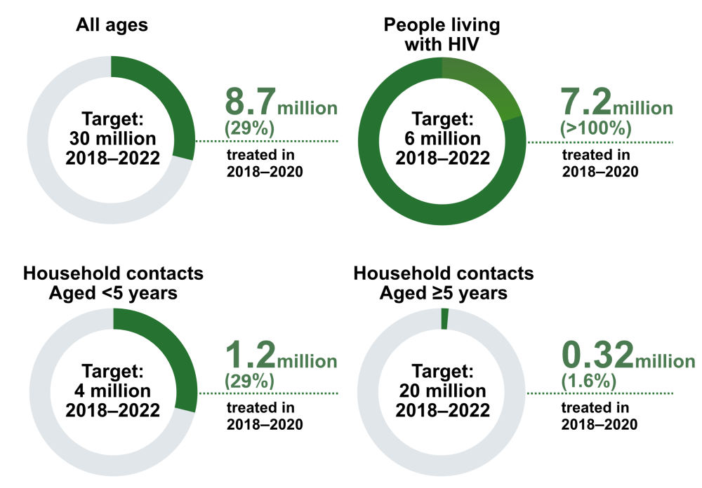

### Fig. 4.3 Percentage of household contacts of bacteriologically confirmed pulmonary new and relapse TB cases evaluated for active TB and TB infection, 2020

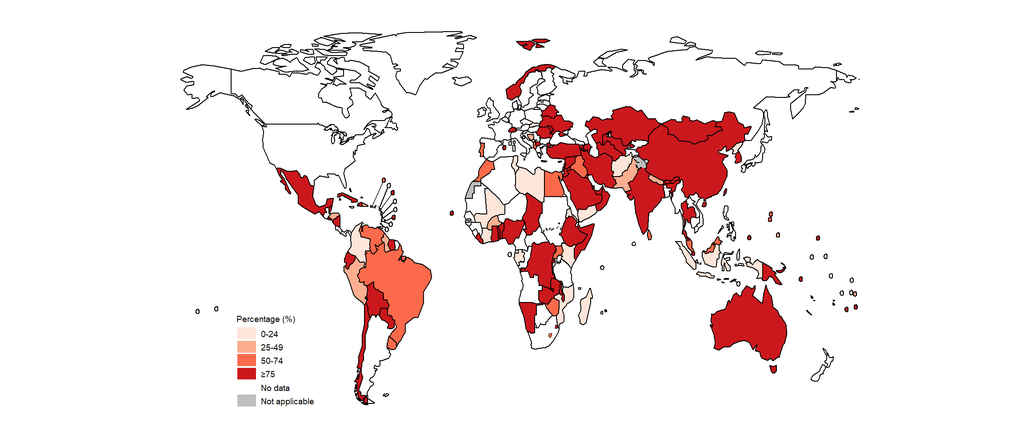

### Fig. 4.4 Coverage of TB preventive treatment among eligible children aged under 5 years,<sup>a</sup> 2020

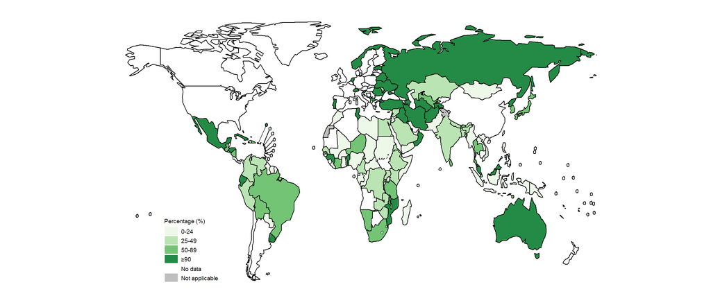

<sup>a</sup> Children aged <5 years who were household contacts of bacteriologically confirmed pulmonary TB cases.

### Fig. 4.5 Completion of TB preventive treatment among contacts starting treatment,<sup>a</sup> 2019

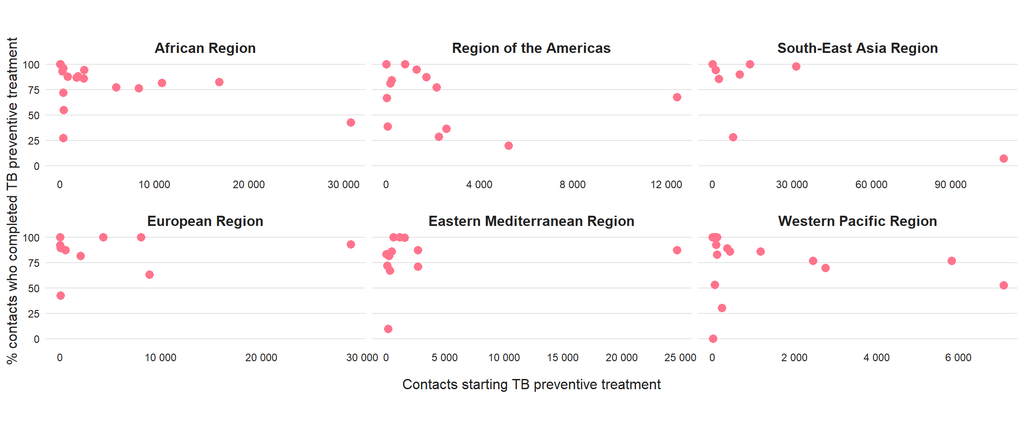

<sup>a</sup> Each dot represents a country report.

### Fig. 4.6 Provision of TB preventive treatment to people living with HIV<sup>a</sup>, 2005–2020

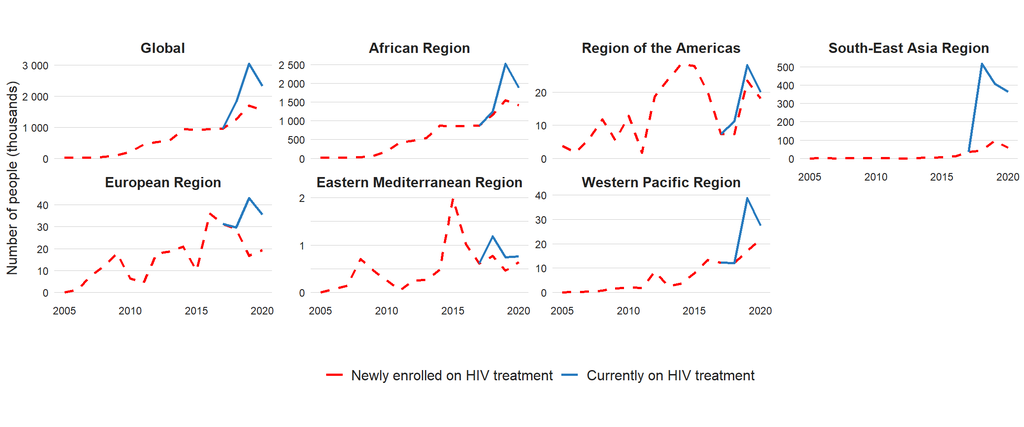

<sup>a</sup> For the period 2005–2016, countries were requested to report data for people newly enrolled in HIV care (dashed lines). Subsequently, countries have been encouraged to report data for people currently on antiretroviral treatment (solid lines).

### Fig. 4.7 The top six countries providing TB preventive treatment to people enrolled on HIV treatment, 2020

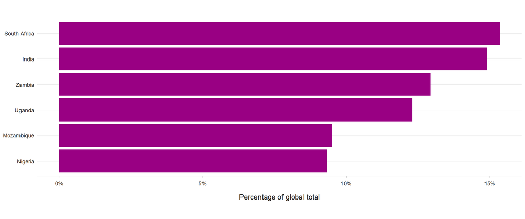

### Fig. 4.8 Use of rifapentine in TB preventive treatment regimens,<sup>a</sup> by June 2021

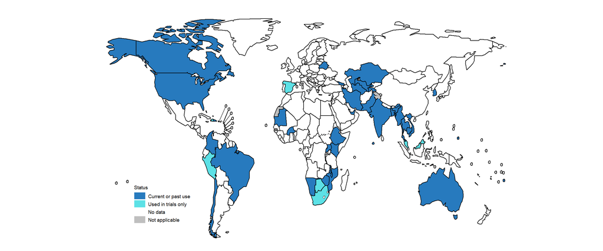

<sup>a</sup> Rifapentine is currently registered for use in China, Hong Kong Special Administrative Region, the Democratic Republic of the Congo, Ethiopia, Ghana, India, Indonesia, Mongolia, Myanmar, the Philippines, Singapore, South Africa, Thailand, Turkmenistan, Uganda and the United States of America (source: Sanofi, June 2021). Several countries in which rifapentine is not yet registered have accessed it using local waiver mechanisms.

### Fig. 4.9 Notification rate ratio of TB among health care workers compared with the adult population, 2020

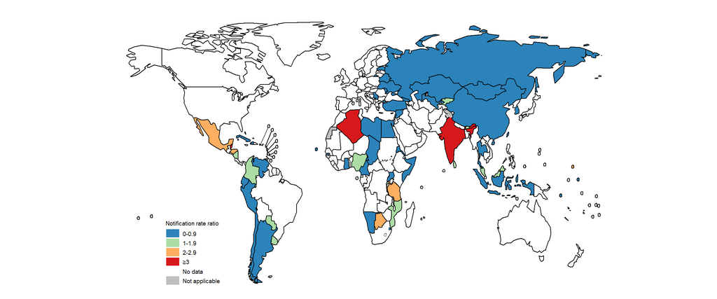

### Fig. 4.10 BCG vaccination practices by country

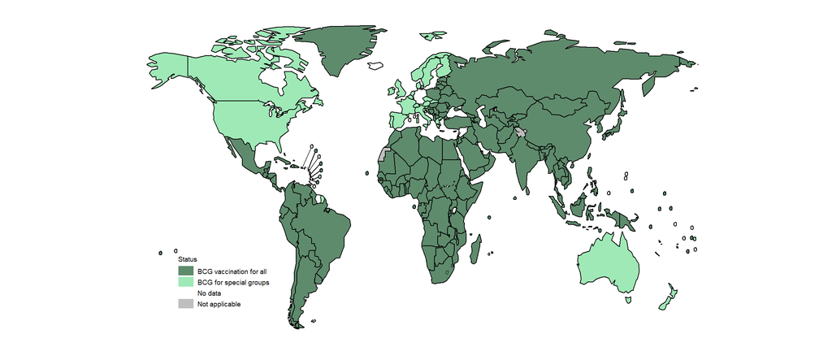

Source: The BCG World Atlas 3rd Edition, http://www.bcgatlas.org/